# Software defects research

Antonio Collante Caro (111 227 429)

08 April, 2020

# 1 Problem - defect in Software quality

## 1.1 Description

In the context of Software Engineering, software quality refers to : 1. the degree to which the correct software was produced and 2. the degree to which the software works as needed.

Maintainability includes concepts of modularity, understandability, changeability, testability, reusability, and transferability from one development team to another. These do not take the form of critical issues at the code level. Rather, poor maintainability is typically the result of thousands of minor violations with best practices in documentation, complexity avoidance strategy, and basic programming practices that make the difference between clean and easy-to-read code vs. unorganized and difficult-to-read code

That being said, one of the major concerns in Software Engineering is to deliver software solutions that comply with quality mainly to *`maintainability`*. I selected a research topic that has to do with *`the relationship between McCabe software metrics and Halstead measures and the reported defects`*.

## 1.2 Dataset

Data comes from McCabe and Halstead features extractors of source code. These features were defined in an attempt to objectively characterize code features that are associated with software quality.

```
## [1] "data/softwaremetrics.csv"
```

## 1.3 After the import

- *Number of observations:*

```
##   count
## 1 10885
```

```
##   loc v_g ev_g iv_g   n       v    l     d     i       e    b       t
## 1   1   1    1    1   1    1.30 1.30  1.30  1.30     1.3 1.30    1.30
## 2   1   1    1    1   1    1.00 1.00  1.00  1.00     1.0 1.00    1.00
## 3  72   7    1    6 198 1134.13 0.05 20.31 55.85 23029.1 0.38 1279.39
##   lOCode lOComment lOBlank lOCodeAndComment uniq_Op uniq_Opnd total_Op
## 1      2         2       2                2     1.2       1.2      1.2
## 2      1         1       1                1     1.0       1.0      1.0
## 3     51        10       8                1    17.0      36.0    112.0
##   total_Opnd branchCount defects
## 1        1.2         1.4   FALSE
## 2        1.0         1.0    TRUE
## 3       86.0        13.0    TRUE
```

- *Attribute Information (22 columns) :*  
  5 different lines of code measure,  
  3 McCabe metrics,  
  4 base Halstead measures,  
  8 derived Halstead measures,  
  1 branch-count,  
  1 goal field

```
## $loc
## [1] "integer"
##
## $v_g
## [1] "integer"
##
## $ev_g
## [1] "integer"
##
## $iv_g
## [1] "integer"
##
## $n
## [1] "integer"
##
## $v
## [1] "double"
##
## $l
## [1] "double"
##
## $d
## [1] "double"
##
## $i
## [1] "double"
##
## $e
## [1] "double"
##
## $b
## [1] "double"
##
## $t
## [1] "double"
##
## $lOCode
## [1] "integer"
##
## $lOComment
```

[output cut: 10 more lines]

```
##
## $uniq_Opnd
## [1] "double"
##
## $total_Op
## [1] "double"
##
## $total_Opnd
## [1] "double"
##
## $branchCount
## [1] "double"
##
## $defects
## [1] "logical"
```

# 2 Exploratory Data Analysis - EDA

## 2.1 Data analysis and manipulation

*`Number of missing values:`*

```
##   na_count
## 1       25
```

```
##   loc v_g ev_g iv_g   n       v    l     d     i        e    b       t
## 1  49   4    3    3 185 1097.19 0.05 18.84 58.25 20667.93 0.37 1148.22
## 2  27   5    3    3  79  417.55 0.07 13.52 30.88  5646.37 0.14  313.69
## 3  76  18   11   11 275 1650.00 0.03 34.50 47.83 56925.00 0.55 3162.50
## 4   6   1    1    1  15   51.89 0.34  2.92 17.79   151.35 0.02    8.41
## 5   9  13   10    4   0    0.00 0.00  0.00  0.00     0.00 0.00    0.00
##   lOCode lOComment lOBlank lOCodeAndComment uniq_Op uniq_Opnd total_Op
## 1     38         0       9                0      NA        NA       NA
## 2     19         0       6                0      NA        NA       NA
## 3     62         0      12                0      NA        NA       NA
## 4      3         0       1                0      NA        NA       NA
## 5      0         0       0                0      NA        NA       NA
##   total_Opnd branchCount defects
## 1         NA          NA    TRUE
## 2         NA          NA    TRUE
## 3         NA          NA    TRUE
## 4         NA          NA   FALSE
## 5         NA          NA   FALSE
```

```
## 'data.frame':    10885 obs. of  22 variables:
##  $ loc             : int  1 1 72 190 37 31 78 8 24 143 ...
##  $ v_g             : int  1 1 7 3 4 2 9 1 2 22 ...
##  $ ev_g            : int  1 1 1 1 1 1 5 1 1 20 ...
##  $ iv_g            : int  1 1 6 3 4 2 4 1 2 10 ...
##  $ n               : int  1 1 198 600 126 111 0 16 0 0 ...
##  $ v               : num  1.3 1 1134.1 4348.8 599.1 ...
##  $ l               : num  1.3 1 0.05 0.06 0.06 0.08 0 0.36 0 0 ...
##  $ d               : num  1.3 1 20.3 17.1 17.2 ...
##  $ i               : num  1.3 1 55.9 254.9 34.9 ...
##  $ e               : num  1.3 1 23029.1 74202.7 10297.3 ...
##  $ b               : num  1.3 1 0.38 1.45 0.2 0.19 0 0.02 0 0 ...
##  $ t               : num  1.3 1 1279.4 4122.4 572.1 ...
##  $ lOCode          : int  2 1 51 129 28 19 0 5 0 0 ...
##  $ lOComment       : int  2 1 10 29 1 0 0 0 0 0 ...
##  $ lOBlank         : int  2 1 8 28 6 5 0 1 0 0 ...
##  $ lOCodeAndComment: int  2 1 1 2 0 0 0 0 0 0 ...
##  $ uniq_Op         : num  1.2 1 17 17 11 14 0 4 0 0 ...
##  $ uniq_Opnd       : num  1.2 1 36 135 16 24 0 5 0 0 ...
##  $ total_Op        : num  1.2 1 112 329 76 69 0 9 0 0 ...
##  $ total_Opnd      : num  1.2 1 86 271 50 42 0 7 0 0 ...
##  $ branchCount     : num  1.4 1 13 5 7 3 17 1 3 43 ...
##  $ defects         : logi  FALSE TRUE TRUE TRUE TRUE TRUE ...
```

I removed the NA’s values from the columns prevously displayed by calculating and assigning the MEAN value to the NA’s found.  
*`Number of missing values after manipulation of the NA's:`*

```
##  [1] loc              v_g              ev_g             iv_g
##  [5] n                v                l                d
##  [9] i                e                b                t
## [13] lOCode           lOComment        lOBlank          lOCodeAndComment
## [17] uniq_Op          uniq_Opnd        total_Op         total_Opnd
## [21] branchCount      defects
## <0 rows> (or 0-length row.names)
```

## 2.2 Correlation between variables

Following it is shown the corralation between *`the McCabe metrics and Halstead measures`* and *`the reported defects`* per modules:

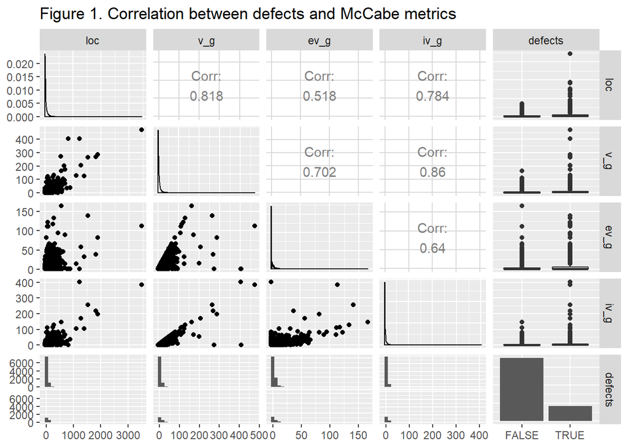

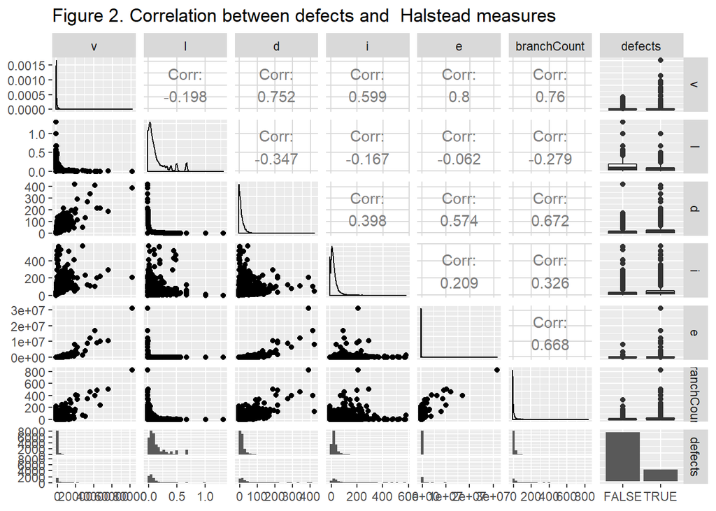

```
## [1] "First 10 observations of McCabe subset"
```

```
##    loc v_g ev_g iv_g       v    l     d      i        e branchCount
## 1    1   1    1    1    1.30 1.30  1.30   1.30     1.30         1.4
## 2    1   1    1    1    1.00 1.00  1.00   1.00     1.00         1.0
## 3   72   7    1    6 1134.13 0.05 20.31  55.85 23029.10        13.0
## 4  190   3    1    3 4348.76 0.06 17.06 254.87 74202.67         5.0
## 5   37   4    1    4  599.12 0.06 17.19  34.86 10297.30         7.0
## 6   31   2    1    2  582.52 0.08 12.25  47.55  7135.87         3.0
## 7   78   9    5    4    0.00 0.00  0.00   0.00     0.00        17.0
## 8    8   1    1    1   50.72 0.36  2.80  18.11   142.01         1.0
## 9   24   2    1    2    0.00 0.00  0.00   0.00     0.00         3.0
## 10 143  22   20   10    0.00 0.00  0.00   0.00     0.00        43.0
##    defects
## 1    FALSE
## 2     TRUE
## 3     TRUE
## 4     TRUE
## 5     TRUE
## 6     TRUE
## 7     TRUE
## 8     TRUE
## 9     TRUE
## 10    TRUE
```

# 3 k-nearest neighbors (KNNs) Model

## 3.1 Parameters

I chose the *`k-nearest neighbors (KNNs) model for classification using the Caret package`* to study the selected research topic. During the EDA, I realized that there were some variables whose values are on widely different scales, the distance value between samples will be biased towards predictors with larger scales. To allow each predictor to contribute equally to the distance calculation, it is recommended to center and scale to avoid bias. So, I applied preProc = c(“center”,“scale”) within the *`Train`* method.

train( Class ~ .,  
data = data.training,  
method = “knn”,  
**preProc = c(“center”, “scale”)**,  
trControl = trainControl_,  
tuneLength = 10  
)

I created the *`training and test partition`* by applying the the 80:20 rules: 80% of samples for training and 20% for testing. Then, I created the model as follows:  
trainControl_ : trainControl(method = “repeatedcv”, number = 10, repeats = 10 )  
tuneLength = 10

To modify the resampling method, a *`trainControl`* function is used. The *`repeatedcv`* is used to specify repeated K-fold cross-validation (and the argument repeats controls the number of repetitions). K is controlled by the number argument and defaults to 10. The *`repeatedcv`* in this case means that each repeat is random split of data into 10 fold, where training/testing data in first iteration of Repeat1 will not be same as Repeat2 and so on. This indicates taht repeating k-fold cross-validation can be used to effectively increase the precision of the estimates while still maintaining a small bias.

Reference to the Caret package: https://cran.r-project.org/web/packages/caret/vignettes/caret.html

## 3.2 Training

**Note:** I created a function *`run_model`* where I run the KNN model based on some parameters (outfile , method, dataset, trainControl). In addition, since running the KNN model could be a time consuming task, I saved the model in the knn.rds file to avoid the execution of the model at every time the project is ran. So if the file exists, the model will be read from the file; otherwise it will be calculated by executing the function run_model.

Based on the Accuracy values from the training dataset, the value used for the model was k = 21 as shown in figure 3.

```
## [1] "knn"
## [1] "Load model from file"
```

```
## k-Nearest Neighbors
##
## 8676 samples
##   10 predictor
##    2 classes: 'FALSE', 'TRUE'
##
## Pre-processing: centered (10), scaled (10)
## Resampling: Cross-Validated (10 fold, repeated 10 times)
## Summary of sample sizes: 7808, 7808, 7808, 7808, 7808, 7809, ...
## Resampling results across tuning parameters:
##
##   k   Accuracy   Kappa
##    5  0.7962073  0.1964480
##    7  0.8023629  0.1885128
##    9  0.8041265  0.1821391
##   11  0.8062586  0.1804652
##   13  0.8076759  0.1753873
##   15  0.8075719  0.1660820
##   17  0.8091511  0.1634189
##   19  0.8101310  0.1633046
##   21  0.8108916  0.1625125
##   23  0.8102456  0.1576774
##
## Accuracy was used to select the optimal model using the largest value.
## The final value used for the model was k = 21.
```

Following in figure 3, it is shown The final value used for the model of k = 21 obtained during the training:

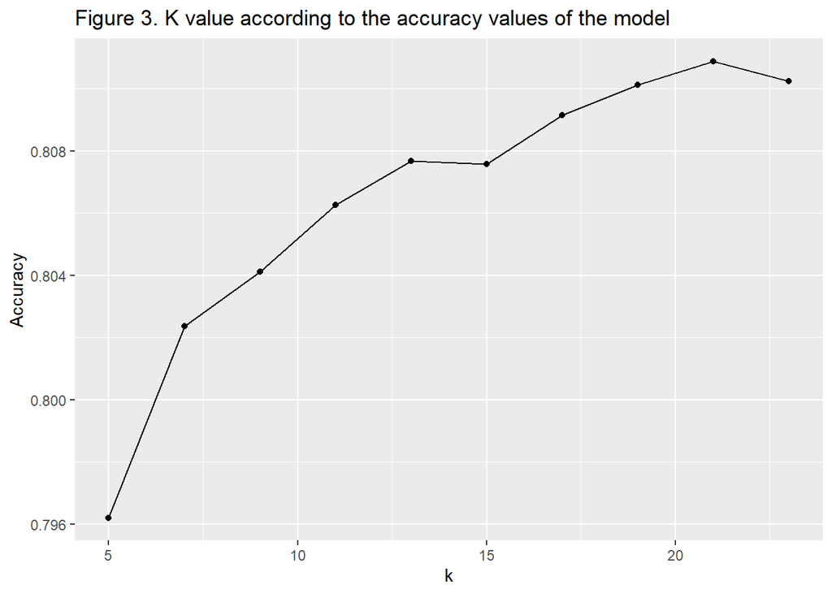

Here it is shown the *`returning predicted probabilities`* for the first 10 observations in the *`training set`*. These are the probabilities for both possible classes, stored in columns

```
##        FALSE       TRUE
## 1  0.9856115 0.01438849
## 2  0.9856115 0.01438849
## 3  0.7142857 0.28571429
## 4  0.6190476 0.38095238
## 5  0.8095238 0.19047619
## 6  0.7142857 0.28571429
## 7  0.8205128 0.17948718
## 8  0.7619048 0.23809524
## 9  0.2857143 0.71428571
## 10 0.5714286 0.42857143
```

## 3.2 Predict

Here it is shown the returning *`predicted probabilities`* for the first 10 observations in the *`test set`*. These are the probabilities for both possible classes, stored in columns

```
##        FALSE       TRUE
## 1  0.9523810 0.04761905
## 2  0.2857143 0.71428571
## 3  0.9655172 0.03448276
## 4  0.7619048 0.23809524
## 5  0.8095238 0.19047619
## 6  0.7142857 0.28571429
## 7  0.4761905 0.52380952
## 8  1.0000000 0.00000000
## 9  0.7619048 0.23809524
## 10 0.7619048 0.23809524
```

## 3.3 Evaluation

### 3.3.1 Classification error

```
## [1] 0.1883205
```

### 3.3.2 Confusion Matrix

```
##          actual
## predicted FALSE TRUE
##     FALSE  1736  373
##     TRUE     43   57
```

```
##    Accuracy Sensitivity Specificity
##   0.8116795   0.9758291   0.1325581
```

The *`sensitivity or true positive rate`* of the model is 0.9758. This mesuares the accuracy in the event population. This describes what proportion of free of defect software modules are correctly identified as having no defects. If this value is high means that we are not missing or excluding many software modules with no defects. If low, the sofware modules will not get the correction or the attention required.

The *`specificity or true negative rate`* of the model is 0.1325 meaning the rate of “defects” software modules that are identified as “defects”. If this is high means that “defect” in software modules are actually classified as “defect”. This statistic is very important as we are intersted in knowing the observations classified as no defect (low rate), but they could lead to a defect in the quality of the software.

```
##    Accuracy Sensitivity Specificity
##   0.8116795   0.9758291   0.1325581
```